# Udacity_project2

Forth: Data Visualization .

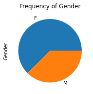

```python
# Column "2" Gender:
data['Gender'].value_counts().plot(kind='pie',figsize=(3,3), title='Frequency of Gender');
```

**Through the above plot, we find that the number of females in the sample is higher than males.**

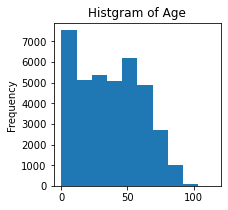

```python
# Column "3" Age:
data['Age'].plot(kind='hist',figsize=(3,3),title='Histgram of Age')
```

**As we can see in the above figure, the age group that represents the largest number of patients is between ages 0 to 10.**

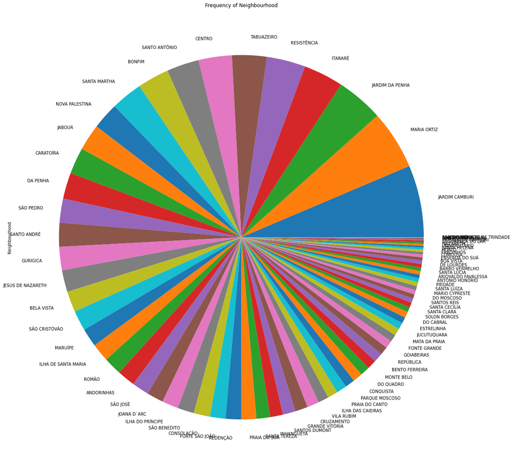

```python
# Column "4" Neighbourhood:
data['Neighbourhood'].value_counts().plot(kind='pie',figsize=(20,20),title='Frequency of Neighbourhood');
```

**Through the above plot, we find that the number of JARDIM CAMBURI in the sample is highest.**

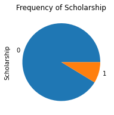

```python
# Column "5" Scholarship:
data['Scholarship'].value_counts().plot(kind='pie',figsize=(3,3),title='Frequency of Scholarship');
```

**Through the above plot, we find that the number of Not having a scholarship in the sample is higher than having a scholarship.**

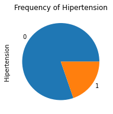

```python
# Column "6" Hipertension:
data['Hipertension'].value_counts().plot(kind='pie',figsize=(3,3),title='Frequency of Hipertension');
```

**Through the above plot, we find that the number of non-hypertensive patient in the sample is higher than hypertensive patient.**

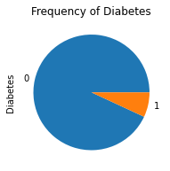

```python
# Column "7" Diabetes:
data['Diabetes'].value_counts().plot(kind='pie',figsize=(3,3),title='Frequency of Diabetes');
```

**Through the above plot, we find that the number of non-diabetic patient in the sample is higher than diabetic patient .**

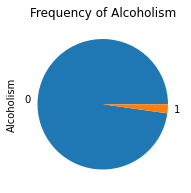

```python
# Column "8" Alcoholism:
data['Alcoholism'].value_counts().plot(kind='pie',figsize=(3,3),title='Frequency of Alcoholism');
```

**Through the above plot, we find that the number of Non alcoholic in the sample is higher than alcoholic .**

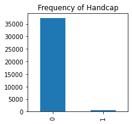

```python
# Column "9" Handcap:
data['Handcap'].value_counts().plot(kind='bar',figsize=(3,3),title='Frequency of Handcap');
```

**Through the above plot, we find that the number of no has disability in the sample is higher than has disability.**

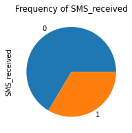

```python
# Column "10" SMS_received:
data['SMS_received'].value_counts().plot(kind='pie',figsize=(3,3),title='Frequency of SMS_received');
```

**Through the above plot, we find that the number of non SMS received in the sample is higher than SMS received.**

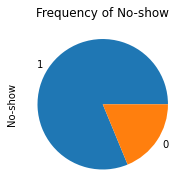

```python
# Column "11" No-show:
data['No-show'].value_counts().plot(kind='pie',figsize=(3,3),title='Frequency of No-show');
```

**Through the above plot, we find that the number of patient showed up to their appointment in the sample is higher than did not show up.**

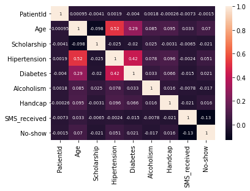

```python
import seaborn as sn
corr_matrix = data.corr()
sn.heatmap(corr_matrix, annot=True ,annot_kws={"size":7})
plt.show()
```

**Statistically, the correlation calculation is incorrect and has no logical explanation except in one case, which is that the first variable is numerical and the second variable is numerical also. Otherwise, it goes back to the nonparametric tests such as: The Chi-Square.**

**One of the most important problems that we faced in this project is that there are columns that contain input errors, for example, column Handcap contains more than two variables, and column Age contains irrational ages such as -1, and these problems were solved.**